# Personal Loan Campaign Modelling

by Michele Casalgrandi

### Background

AllLife is a US bank. The majority of AllLife customers are depositors (liability customers).

The number of customers who are also borrowers (asset customers) is low. The bank is interested in converting its liability customers to personal loan customers and raise earnings through interest on loans.

While the past year campaign had a good conversion rate of 9%, the marketing department is working on better targeted campaigns in order to improve the success rate

### Objectives

1. Predict whether a liability customer will buy a personal loan
2. Identify which variables are most significant
3. Identify which segment of customers should be targeted more

### Data Dictionary

- ID: Customer ID
- Age: Customer’s age in completed years
- Experience: number of years of professional experience
- Income: Annual income of the customer (in thousand dollars)
- ZIP Code: Home Address ZIP code
- Family: the Family size of the customer
- CCAvg: Average spending on credit cards per month (in thousand dollars)
- Education: Education Level. 1: Undergrad; 2: Graduate;3: Advanced/Professional
- Mortgage: Value of house mortgage if any. (in thousand dollars)
- Personal_Loan: Did this customer accept the personal loan offered in the last campaign?
- Securities_Account: Does the customer have securities account with the bank?
- CD_Account: Does the customer have a certificate of deposit (CD) account with the bank?
- Online: Do customers use internet banking facilities?
- CreditCard: Does the customer use a credit card issued by any other Bank (excluding All life Bank)?

##### Import needed libraries and data

```python
import pandas as pd
import numpy as np
import matplotlib.pyplot as plt
import seaborn as sns

sns.set()

import warnings

warnings.filterwarnings("ignore")

# Removes the limit for the number of displayed columns
pd.set_option("display.max_columns", None)
# Sets the limit for the number of displayed rows
pd.set_option("display.max_rows", 200)

# To build linear model for prediction
from sklearn.linear_model import LogisticRegression
from sklearn.tree import DecisionTreeClassifier
from sklearn import tree
from sklearn.model_selection import train_test_split

# To check model performance
from sklearn import metrics
```

```python
# Load dataset
df = pd.read_csv("Loan_Modelling.csv")

# get shape
print(f"There are {df.shape[0]} rows and {df.shape[1]} columns.")
```

```
There are 5000 rows and 14 columns.
```

```python
# show columns
df.columns
```

```
Index(['ID', 'Age', 'Experience', 'Income', 'ZIPCode', 'Family', 'CCAvg',
       'Education', 'Mortgage', 'Personal_Loan', 'Securities_Account',
       'CD_Account', 'Online', 'CreditCard'],
      dtype='object')
```

```python
# Show columns types
df.dtypes
```

```
ID                      int64
Age                     int64
Experience              int64
Income                  int64
ZIPCode                 int64
Family                  int64
CCAvg                 float64
Education               int64
Mortgage                int64
Personal_Loan           int64
Securities_Account      int64
CD_Account              int64
Online                  int64
CreditCard              int64
dtype: object
```

All columns are stored as numbers

```python
# view beginning of data set
df.head(10)
```

|  | ID | Age | Experience | Income | ZIPCode | Family | CCAvg | Education | Mortgage | Personal_Loan | Securities_Account | CD_Account | Online | CreditCard |
| --- | --- | --- | --- | --- | --- | --- | --- | --- | --- | --- | --- | --- | --- | --- |
| 0 | 1 | 25 | 1 | 49 | 91107 | 4 | 1.6 | 1 | 0 | 0 | 1 | 0 | 0 | 0 |
| 1 | 2 | 45 | 19 | 34 | 90089 | 3 | 1.5 | 1 | 0 | 0 | 1 | 0 | 0 | 0 |
| 2 | 3 | 39 | 15 | 11 | 94720 | 1 | 1.0 | 1 | 0 | 0 | 0 | 0 | 0 | 0 |
| 3 | 4 | 35 | 9 | 100 | 94112 | 1 | 2.7 | 2 | 0 | 0 | 0 | 0 | 0 | 0 |
| 4 | 5 | 35 | 8 | 45 | 91330 | 4 | 1.0 | 2 | 0 | 0 | 0 | 0 | 0 | 1 |
| 5 | 6 | 37 | 13 | 29 | 92121 | 4 | 0.4 | 2 | 155 | 0 | 0 | 0 | 1 | 0 |
| 6 | 7 | 53 | 27 | 72 | 91711 | 2 | 1.5 | 2 | 0 | 0 | 0 | 0 | 1 | 0 |
| 7 | 8 | 50 | 24 | 22 | 93943 | 1 | 0.3 | 3 | 0 | 0 | 0 | 0 | 0 | 1 |
| 8 | 9 | 35 | 10 | 81 | 90089 | 3 | 0.6 | 2 | 104 | 0 | 0 | 0 | 1 | 0 |
| 9 | 10 | 34 | 9 | 180 | 93023 | 1 | 8.9 | 3 | 0 | 1 | 0 | 0 | 0 | 0 |

```python
# view end of data set
df.tail(10)
```

|  | ID | Age | Experience | Income | ZIPCode | Family | CCAvg | Education | Mortgage | Personal_Loan | Securities_Account | CD_Account | Online | CreditCard |
| --- | --- | --- | --- | --- | --- | --- | --- | --- | --- | --- | --- | --- | --- | --- |
| 4990 | 4991 | 55 | 25 | 58 | 95023 | 4 | 2.00 | 3 | 219 | 0 | 0 | 0 | 0 | 1 |
| 4991 | 4992 | 51 | 25 | 92 | 91330 | 1 | 1.90 | 2 | 100 | 0 | 0 | 0 | 0 | 1 |
| 4992 | 4993 | 30 | 5 | 13 | 90037 | 4 | 0.50 | 3 | 0 | 0 | 0 | 0 | 0 | 0 |
| 4993 | 4994 | 45 | 21 | 218 | 91801 | 2 | 6.67 | 1 | 0 | 0 | 0 | 0 | 1 | 0 |
| 4994 | 4995 | 64 | 40 | 75 | 94588 | 3 | 2.00 | 3 | 0 | 0 | 0 | 0 | 1 | 0 |
| 4995 | 4996 | 29 | 3 | 40 | 92697 | 1 | 1.90 | 3 | 0 | 0 | 0 | 0 | 1 | 0 |
| 4996 | 4997 | 30 | 4 | 15 | 92037 | 4 | 0.40 | 1 | 85 | 0 | 0 | 0 | 1 | 0 |
| 4997 | 4998 | 63 | 39 | 24 | 93023 | 2 | 0.30 | 3 | 0 | 0 | 0 | 0 | 0 | 0 |
| 4998 | 4999 | 65 | 40 | 49 | 90034 | 3 | 0.50 | 2 | 0 | 0 | 0 | 0 | 1 | 0 |
| 4999 | 5000 | 28 | 4 | 83 | 92612 | 3 | 0.80 | 1 | 0 | 0 | 0 | 0 | 1 | 1 |

```python
# set random seed for repeatability
np.random.seed(1)

# view data sample
df.sample(5)
```

|  | ID | Age | Experience | Income | ZIPCode | Family | CCAvg | Education | Mortgage | Personal_Loan | Securities_Account | CD_Account | Online | CreditCard |
| --- | --- | --- | --- | --- | --- | --- | --- | --- | --- | --- | --- | --- | --- | --- |
| 2764 | 2765 | 31 | 5 | 84 | 91320 | 1 | 2.9 | 3 | 105 | 0 | 0 | 0 | 0 | 1 |
| 4767 | 4768 | 35 | 9 | 45 | 90639 | 3 | 0.9 | 1 | 101 | 0 | 1 | 0 | 0 | 0 |
| 3814 | 3815 | 34 | 9 | 35 | 94304 | 3 | 1.3 | 1 | 0 | 0 | 0 | 0 | 0 | 0 |
| 3499 | 3500 | 49 | 23 | 114 | 94550 | 1 | 0.3 | 1 | 286 | 0 | 0 | 0 | 1 | 0 |
| 2735 | 2736 | 36 | 12 | 70 | 92131 | 3 | 2.6 | 2 | 165 | 0 | 0 | 0 | 1 | 0 |

```python
# get statistics
df.describe().T
```

|  | count | mean | std | min | 25% | 50% | 75% | max |
| --- | --- | --- | --- | --- | --- | --- | --- | --- |
| ID | 5000.0 | 2500.500000 | 1443.520003 | 1.0 | 1250.75 | 2500.5 | 3750.25 | 5000.0 |
| Age | 5000.0 | 45.338400 | 11.463166 | 23.0 | 35.00 | 45.0 | 55.00 | 67.0 |
| Experience | 5000.0 | 20.104600 | 11.467954 | -3.0 | 10.00 | 20.0 | 30.00 | 43.0 |
| Income | 5000.0 | 73.774200 | 46.033729 | 8.0 | 39.00 | 64.0 | 98.00 | 224.0 |
| ZIPCode | 5000.0 | 93169.257000 | 1759.455086 | 90005.0 | 91911.00 | 93437.0 | 94608.00 | 96651.0 |
| Family | 5000.0 | 2.396400 | 1.147663 | 1.0 | 1.00 | 2.0 | 3.00 | 4.0 |
| CCAvg | 5000.0 | 1.937938 | 1.747659 | 0.0 | 0.70 | 1.5 | 2.50 | 10.0 |
| Education | 5000.0 | 1.881000 | 0.839869 | 1.0 | 1.00 | 2.0 | 3.00 | 3.0 |
| Mortgage | 5000.0 | 56.498800 | 101.713802 | 0.0 | 0.00 | 0.0 | 101.00 | 635.0 |
| Personal_Loan | 5000.0 | 0.096000 | 0.294621 | 0.0 | 0.00 | 0.0 | 0.00 | 1.0 |
| Securities_Account | 5000.0 | 0.104400 | 0.305809 | 0.0 | 0.00 | 0.0 | 0.00 | 1.0 |
| CD_Account | 5000.0 | 0.060400 | 0.238250 | 0.0 | 0.00 | 0.0 | 0.00 | 1.0 |
| Online | 5000.0 | 0.596800 | 0.490589 | 0.0 | 0.00 | 1.0 | 1.00 | 1.0 |
| CreditCard | 5000.0 | 0.294000 | 0.455637 | 0.0 | 0.00 | 0.0 | 1.00 | 1.0 |

```python
# check for duplicate ID's
df['ID'].nunique()
```

```
5000
```

```python
# check for duplicates
df.duplicated().sum()
```

```
0
```

```python
# check ZIPCode values
df['ZIPCode'].value_counts()
```

```
94720    169
94305    127
95616    116
90095     71
93106     57
        ...
94970      1
92694      1
94404      1
94598      1
94965      1
Name: ZIPCode, Length: 467, dtype: int64
```

```python
# check Education
df['Education'].value_counts()
```

```
1    2096
3    1501
2    1403
Name: Education, dtype: int64
```

### Data Summary

- ID. Each row has a unique 'ID'. As we are not interested in individual customers as such but in the aggregate, we will drop the ID.
- Age. Ranges from 23 to 67. Average is ~45 and so is the median, suggesting there is little, if any skew.
- Experience. There appear to be one or more invalid entries (e.g. minimum is -3). We will need to address that.
- Income. Range seems reasonable. There is high std deviation and appears to be skewed with outliers.
- ZipCode. It is represented numerically but it's a categorical variable with 467 levels. We'll probably encode the top 10 or so and group the remaining in 'Other'
- Family. Categorical with four levels. Mean of 2.4 and median of 2.
- CCAvg. Ranges from 0 to 10 with some skew.
- Education. Categorical with three levels.
- Mortgage. Most observation have 0 (no mortgage). Mean is 56 and std deviation is high at 102
- Personal_Loan, Securities_Account, CD_Account, Online and CreditCard are categorical variables represented numerically with two levels (0,1)

#### EDA and Preprocessing

```python
# make a copy of the dataset
loans = df.copy()
```

```python
# drop ID
loans.drop('ID', axis=1, inplace=True)
```

```python
# Check for null values
loans.isna().sum()
```

```
Age                   0
Experience            0
Income                0
ZIPCode               0
Family                0
CCAvg                 0
Education             0
Mortgage              0
Personal_Loan         0
Securities_Account    0
CD_Account            0
Online                0
CreditCard            0
dtype: int64
```

There are no nulls in the dataset

We will now group all ZIPCode values not in the top 10 to 'Other'

```python
# Define function to convert zipcode to 'Other' as appropriate
def bin_zipcode(zipcode):
    ''' Returns "Other" for zipcodes not in zipcode_top_n
    Returns a string'''
    if zipcode in zipcode_top_n:
        return str(zipcode)
    else:
        return 'Other'
```

```python
zipcode_n = 10
zipcode_top_n = loans['ZIPCode'].value_counts().head(zipcode_n).index.to_list()
zipcode_top_n
```

```
[94720, 94305, 95616, 90095, 93106, 93943, 92037, 91320, 94025, 91711]
```

```python
loans['ZIPCode_cat'] = loans['ZIPCode'].apply(bin_zipcode)
loans['ZIPCode_cat'].value_counts()
```

```
Other    4195
94720     169
94305     127
95616     116
90095      71
93106      57
92037      54
93943      54
91320      53
94025      52
91711      52
Name: ZIPCode_cat, dtype: int64
```

Cast categorical values to category

```python
# set categorical variables
# Exclude those with two level (0,1) as they don't need to be transformed for logistic regression
cat_columns = ['ZIPCode_cat', 'Family', 'Education']
loans[cat_columns] = loans[cat_columns].astype('category')
```

```python
loans.dtypes
```

```
Age                      int64
Experience               int64
Income                   int64
ZIPCode                  int64
Family                category
CCAvg                  float64
Education             category
Mortgage                 int64
Personal_Loan            int64
Securities_Account       int64
CD_Account               int64
Online                   int64
CreditCard               int64
ZIPCode_cat           category
dtype: object
```

```python
# drop ZIPCode
loans.drop('ZIPCode', axis=1, inplace=True)
```

```python
# Check types
loans.dtypes
```

```
Age                      int64
Experience               int64
Income                   int64
Family                category
CCAvg                  float64
Education             category
Mortgage                 int64
Personal_Loan            int64
Securities_Account       int64
CD_Account               int64
Online                   int64
CreditCard               int64
ZIPCode_cat           category
dtype: object
```

```python
# Check negative values for Experience
loans[loans['Experience'] < 0]
```

|  | Age | Experience | Income | Family | CCAvg | Education | Mortgage | Personal_Loan | Securities_Account | CD_Account | Online | CreditCard | ZIPCode_cat |
| --- | --- | --- | --- | --- | --- | --- | --- | --- | --- | --- | --- | --- | --- |
| 89 | 25 | -1 | 113 | 4 | 2.30 | 3 | 0 | 0 | 0 | 0 | 0 | 1 | Other |
| 226 | 24 | -1 | 39 | 2 | 1.70 | 2 | 0 | 0 | 0 | 0 | 0 | 0 | Other |
| 315 | 24 | -2 | 51 | 3 | 0.30 | 3 | 0 | 0 | 0 | 0 | 1 | 0 | Other |
| 451 | 28 | -2 | 48 | 2 | 1.75 | 3 | 89 | 0 | 0 | 0 | 1 | 0 | Other |
| 524 | 24 | -1 | 75 | 4 | 0.20 | 1 | 0 | 0 | 0 | 0 | 1 | 0 | Other |
| 536 | 25 | -1 | 43 | 3 | 2.40 | 2 | 176 | 0 | 0 | 0 | 1 | 0 | Other |
| 540 | 25 | -1 | 109 | 4 | 2.30 | 3 | 314 | 0 | 0 | 0 | 1 | 0 | Other |
| 576 | 25 | -1 | 48 | 3 | 0.30 | 3 | 0 | 0 | 0 | 0 | 0 | 1 | Other |
| 583 | 24 | -1 | 38 | 2 | 1.70 | 2 | 0 | 0 | 0 | 0 | 1 | 0 | Other |
| 597 | 24 | -2 | 125 | 2 | 7.20 | 1 | 0 | 0 | 1 | 0 | 0 | 1 | Other |
| 649 | 25 | -1 | 82 | 4 | 2.10 | 3 | 0 | 0 | 0 | 0 | 1 | 0 | Other |
| 670 | 23 | -1 | 61 | 4 | 2.60 | 1 | 239 | 0 | 0 | 0 | 1 | 0 | Other |
| 686 | 24 | -1 | 38 | 4 | 0.60 | 2 | 0 | 0 | 0 | 0 | 1 | 0 | Other |
| 793 | 24 | -2 | 150 | 2 | 2.00 | 1 | 0 | 0 | 0 | 0 | 1 | 0 | 94720 |
| 889 | 24 | -2 | 82 | 2 | 1.60 | 3 | 0 | 0 | 0 | 0 | 1 | 1 | Other |
| 909 | 23 | -1 | 149 | 1 | 6.33 | 1 | 305 | 0 | 0 | 0 | 0 | 1 | Other |
| 1173 | 24 | -1 | 35 | 2 | 1.70 | 2 | 0 | 0 | 0 | 0 | 0 | 0 | 94305 |
| 1428 | 25 | -1 | 21 | 4 | 0.40 | 1 | 90 | 0 | 0 | 0 | 1 | 0 | Other |
| 1522 | 25 | -1 | 101 | 4 | 2.30 | 3 | 256 | 0 | 0 | 0 | 0 | 1 | 94720 |
| 1905 | 25 | -1 | 112 | 2 | 2.00 | 1 | 241 | 0 | 0 | 0 | 1 | 0 | Other |
| 2102 | 25 | -1 | 81 | 2 | 1.60 | 3 | 0 | 0 | 0 | 0 | 1 | 1 | Other |
| 2430 | 23 | -1 | 73 | 4 | 2.60 | 1 | 0 | 0 | 0 | 0 | 1 | 0 | Other |
| 2466 | 24 | -2 | 80 | 2 | 1.60 | 3 | 0 | 0 | 0 | 0 | 1 | 0 | Other |
| 2545 | 25 | -1 | 39 | 3 | 2.40 | 2 | 0 | 0 | 0 | 0 | 1 | 0 | 94720 |
| 2618 | 23 | -3 | 55 | 3 | 2.40 | 2 | 145 | 0 | 0 | 0 | 1 | 0 | Other |
| 2717 | 23 | -2 | 45 | 4 | 0.60 | 2 | 0 | 0 | 0 | 0 | 1 | 1 | Other |
| 2848 | 24 | -1 | 78 | 2 | 1.80 | 2 | 0 | 0 | 0 | 0 | 0 | 0 | 94720 |
| 2876 | 24 | -2 | 80 | 2 | 1.60 | 3 | 238 | 0 | 0 | 0 | 0 | 0 | Other |
| 2962 | 23 | -2 | 81 | 2 | 1.80 | 2 | 0 | 0 | 0 | 0 | 0 | 0 | 91711 |
| 2980 | 25 | -1 | 53 | 3 | 2.40 | 2 | 0 | 0 | 0 | 0 | 0 | 0 | 94305 |
| 3076 | 29 | -1 | 62 | 2 | 1.75 | 3 | 0 | 0 | 0 | 0 | 0 | 1 | Other |
| 3130 | 23 | -2 | 82 | 2 | 1.80 | 2 | 0 | 0 | 1 | 0 | 0 | 1 | Other |
| 3157 | 23 | -1 | 13 | 4 | 1.00 | 1 | 84 | 0 | 0 | 0 | 1 | 0 | 94720 |
| 3279 | 26 | -1 | 44 | 1 | 2.00 | 2 | 0 | 0 | 0 | 0 | 0 | 0 | Other |
| 3284 | 25 | -1 | 101 | 4 | 2.10 | 3 | 0 | 0 | 0 | 0 | 0 | 1 | Other |
| 3292 | 25 | -1 | 13 | 4 | 0.40 | 1 | 0 | 0 | 1 | 0 | 0 | 0 | 95616 |
| 3394 | 25 | -1 | 113 | 4 | 2.10 | 3 | 0 | 0 | 0 | 0 | 1 | 0 | Other |
| 3425 | 23 | -1 | 12 | 4 | 1.00 | 1 | 90 | 0 | 0 | 0 | 1 | 0 | Other |
| 3626 | 24 | -3 | 28 | 4 | 1.00 | 3 | 0 | 0 | 0 | 0 | 0 | 0 | Other |
| 3796 | 24 | -2 | 50 | 3 | 2.40 | 2 | 0 | 0 | 1 | 0 | 0 | 0 | Other |
| 3824 | 23 | -1 | 12 | 4 | 1.00 | 1 | 0 | 0 | 1 | 0 | 0 | 1 | Other |
| 3887 | 24 | -2 | 118 | 2 | 7.20 | 1 | 0 | 0 | 1 | 0 | 1 | 0 | Other |
| 3946 | 25 | -1 | 40 | 3 | 2.40 | 2 | 0 | 0 | 0 | 0 | 1 | 0 | Other |
| 4015 | 25 | -1 | 139 | 2 | 2.00 | 1 | 0 | 0 | 0 | 0 | 0 | 1 | 93106 |
| 4088 | 29 | -1 | 71 | 2 | 1.75 | 3 | 0 | 0 | 0 | 0 | 0 | 0 | Other |
| 4116 | 24 | -2 | 135 | 2 | 7.20 | 1 | 0 | 0 | 0 | 0 | 1 | 0 | Other |
| 4285 | 23 | -3 | 149 | 2 | 7.20 | 1 | 0 | 0 | 0 | 0 | 1 | 0 | Other |
| 4411 | 23 | -2 | 75 | 2 | 1.80 | 2 | 0 | 0 | 0 | 0 | 1 | 1 | Other |
| 4481 | 25 | -2 | 35 | 4 | 1.00 | 3 | 0 | 0 | 0 | 0 | 1 | 0 | Other |
| 4514 | 24 | -3 | 41 | 4 | 1.00 | 3 | 0 | 0 | 0 | 0 | 1 | 0 | Other |
| 4582 | 25 | -1 | 69 | 3 | 0.30 | 3 | 0 | 0 | 0 | 0 | 1 | 0 | Other |
| 4957 | 29 | -1 | 50 | 2 | 1.75 | 3 | 0 | 0 | 0 | 0 | 0 | 1 | Other |

All negative values are for customers in their 20's with varying Education levels.

```python
# get count of negative experience
loans['Experience'][loans['Experience'] < 0].count()
```

```
52
```

```python
# get count of customers below age 30
loans['Experience'][loans['Age'] < 30].count()
```

```
488
```

```python
# get stats of customers below age 30
loans['Experience'][loans['Age'] < 30].describe()
```

```
count    488.000000
mean       1.969262
std        1.868654
min       -3.000000
25%        1.000000
50%        2.000000
75%        3.000000
max        5.000000
Name: Experience, dtype: float64
```

Customers with negative experience are ~1% of all data and ~ 10% of customers under 30. 75% of people under 30 have 3 or less years of experience. We assume the negative values are data entry errors and impute the absolute value of the experience.

```python
loans['Experience'] = np.abs(loans['Experience'])
loans['Experience'][loans['Age'] < 30].describe()
```

```
count    488.000000
mean       2.276639
std        1.477868
min        0.000000
25%        1.000000
50%        2.000000
75%        3.000000
max        5.000000
Name: Experience, dtype: float64
```

#### Distributions of numerical variables

```python
# define function to plot histogram and boxplot for a feature
def histogram_boxplot(feature, figsize=(15, 10), bins=None):
    """Boxplot and histogram combined
    feature: 1-d feature array
    figsize: size of fig (default (15,10))
    bins: number of bins (default None / auto)
    """
    f2, (ax_box2, ax_hist2) = plt.subplots(
        nrows=2,  # Number of rows of the subplot grid= 2
        sharex=True,  # x-axis will be shared among all subplots
        gridspec_kw={"height_ratios": (0.25, 0.75)},
        figsize=figsize,
    )  # creating the 2 subplots
    sns.boxplot(
        feature, ax=ax_box2, showmeans=True, color="violet"
    )  # boxplot will be created and a star will indicate the mean value of the column
    sns.distplot(
        feature, kde=True, ax=ax_hist2, bins=bins
    ) if bins else sns.distplot(
        feature, kde=False, ax=ax_hist2
    )  # For histogram
    ax_hist2.axvline(
        feature.mean(), color="green", linestyle="--"
    )  # Add mean to the histogram
    ax_hist2.axvline(
        feature.median(), color="black", linestyle="-"
    )  # Add median to the histogram
```

```python
# Get numerical columns
loans.select_dtypes(include=["int64", "float64"]).columns
```

```
Index(['Age', 'Experience', 'Income', 'CCAvg', 'Mortgage', 'Personal_Loan',
       'Securities_Account', 'CD_Account', 'Online', 'CreditCard'],
      dtype='object')
```

##### Age

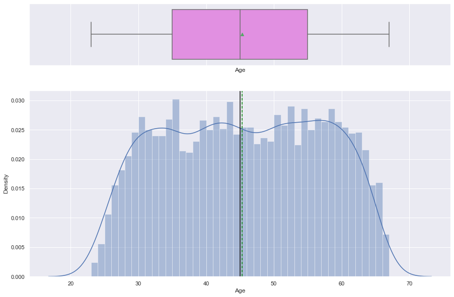

```python
histogram_boxplot(loans['Age'], bins=44)
```

Roughly uniform between 30 and 63 and then it tapers on both ends. No outliers.

##### Experience

```python
loans.Experience.nunique()
```

```
44
```

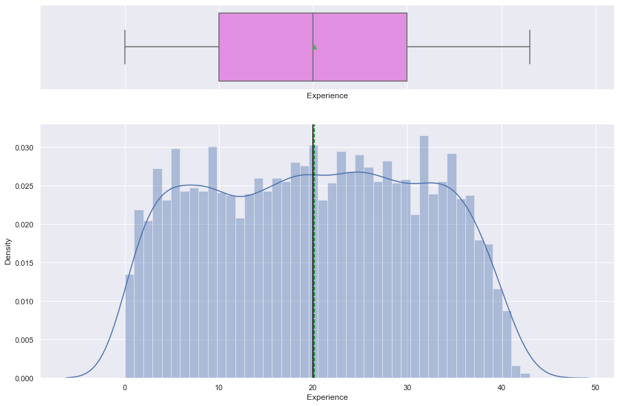

```python
histogram_boxplot(loans['Experience'], bins=44)
```

Roughly uniform between 1 and 36 and tapers at the ends. Slightly skewed to the right.

##### Income

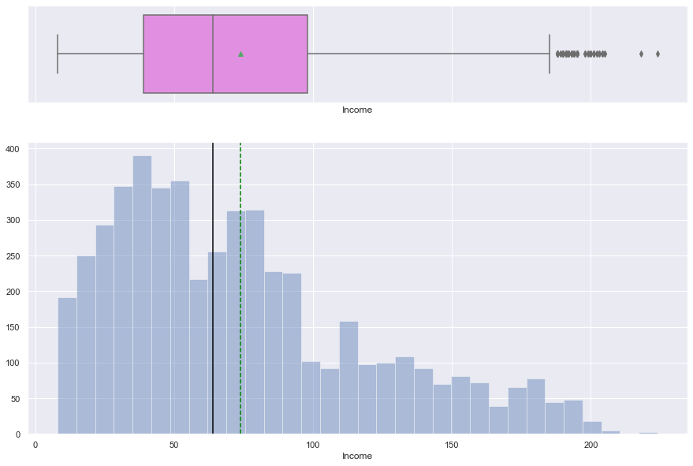

```python
histogram_boxplot(loans['Income'])
```

Bimodal distribution, very skewed to the right.

Although the distribution is skewed, doing a log transform led to very high coefficients for the log-transformed variable.

The same happened by binning income into '< 50' and '> = 50'.

We will leave Income as is.

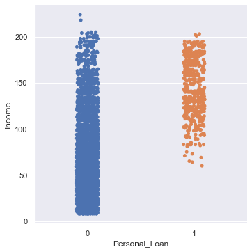

```python
sns.catplot(y='Income',x='Personal_Loan',data=df);
```

##### CCAvg

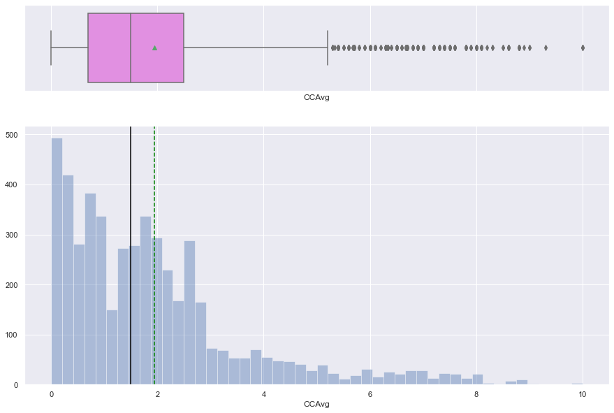

```python
histogram_boxplot(loans['CCAvg'])
```

- CCAvg. Most values are under 3, skewed to the right with long tail.  
  As there are zero values and the dataset contains values below one (less that USD1000) we will impute log of ( CCAvg + half of the smallest non-zero balance ).

```python
# get smallest non-zero CCAvg
cc_avg_nz_min = loans['CCAvg'][loans['CCAvg'] > 0].min()
cc_avg_nz_min
```

```
0.1
```

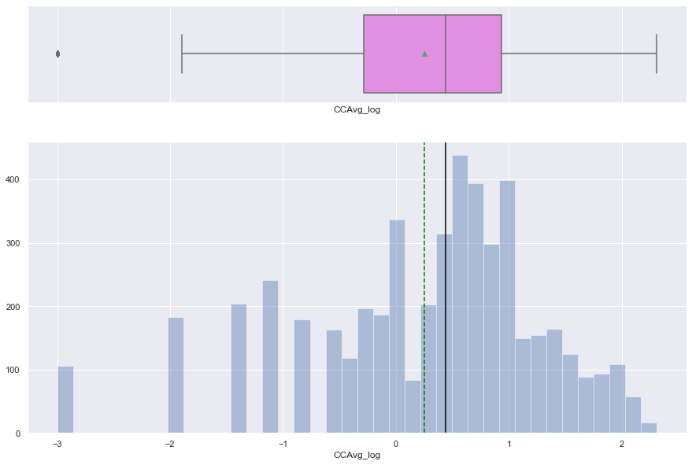

```python
# take log of CCAVG + offset
loans['CCAvg_log'] = np.log(loans['CCAvg'] + cc_avg_nz_min/2)
histogram_boxplot(loans['CCAvg_log'])
```

```python
# drop CCAvg
loans.drop('CCAvg', axis=1, inplace=True)
```

##### Mortgage

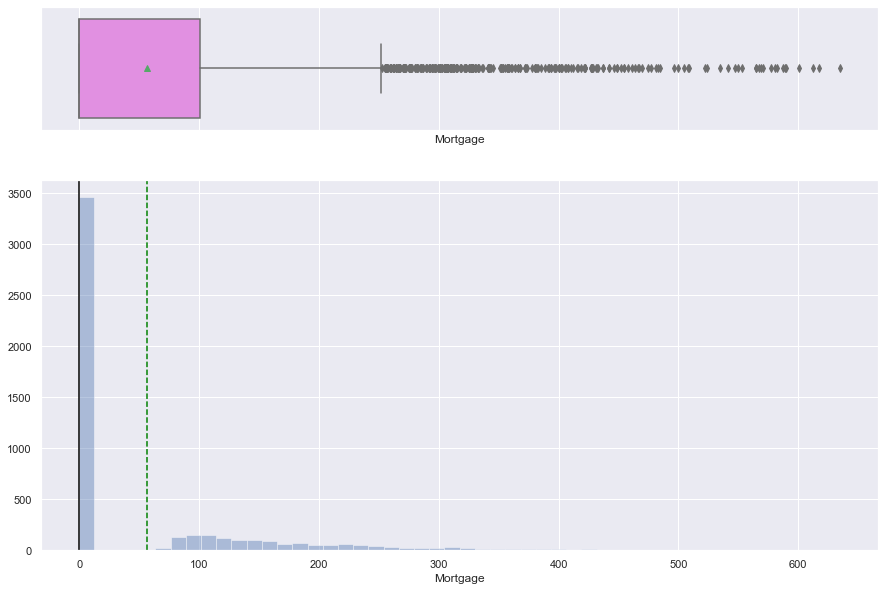

```python
histogram_boxplot(loans['Mortgage'])
```

Most have zero (no mortgage), heavily skewed with many outliers and thin long right tail. Since there are so many zeros, we will bin the variable in different levels.

```python
mortgage_levels = ['0','1 - 100','101 - 200','201 - 300','301 - 400','> 400']
loans['Mortgage_bin'] = pd.cut(
    loans['Mortgage'],
    [-np.inf, 1, 100, 200, 300, 400, np.inf],
    labels = mortgage_levels
)
loans['Mortgage_bin'].head(10)
```

```
0            0
1            0
2            0
3            0
4            0
5    101 - 200
6            0
7            0
8    101 - 200
9            0
Name: Mortgage_bin, dtype: category
Categories (6, object): ['0' < '1 - 100' < '101 - 200' < '201 - 300' < '301 - 400' < '> 400']
```

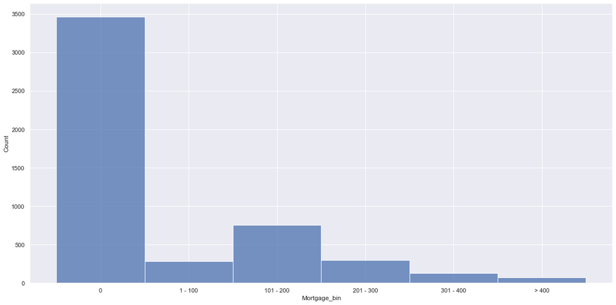

```python
sns.displot(loans['Mortgage_bin'], height=8, aspect=2);
```

```python
# Drop Mortgage
loans.drop('Mortgage', axis=1, inplace=True)
```

### Categorical Variables

```python
loans.dtypes
```

```
Age                      int64
Experience               int64
Income                   int64
Family                category
Education             category
Personal_Loan            int64
Securities_Account       int64
CD_Account               int64
Online                   int64
CreditCard               int64
ZIPCode_cat           category
CCAvg_log              float64
Mortgage_bin          category
dtype: object
```

```python
# Function to create barplots that indicate percentage for each category.

def perc_on_bar(z):
    '''
    plot
    feature: categorical feature
    the function won't work if a column is passed in hue parameter
    '''

    total = len(z) # length of the column
    plt.figure(figsize=(15,5))
    #plt.xticks(rotation=45)
    ax = sns.countplot(z,palette='Paired')
    for p in ax.patches:
        percentage = '{:.1f}%'.format(100 * p.get_height()/total) # percentage of each class of the category
        x = p.get_x() + p.get_width() / 2 - 0.05 # width of the plot
        y = p.get_y() + p.get_height()           # hieght of the plot

        ax.annotate(percentage, (x, y), size = 12) # annotate the percentage
    plt.show() # show the plot
```

##### Family

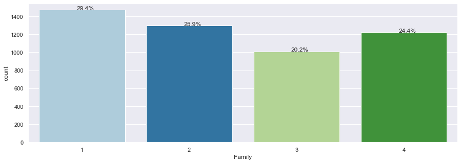

```python
perc_on_bar(loans['Family'])
```

##### Education

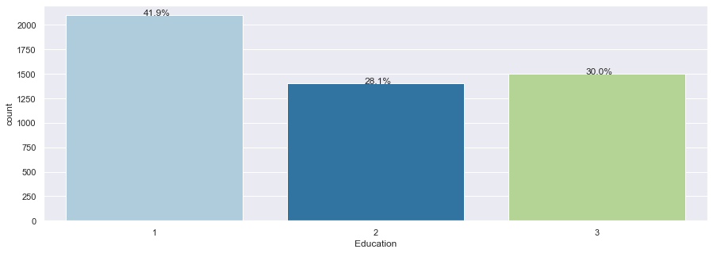

```python
perc_on_bar(loans['Education'])
```

42% have undergraduate education (1), followed by Advanced/Professional (3) at 30% and last Graduate (2) at 28%

##### Mortgage_bin

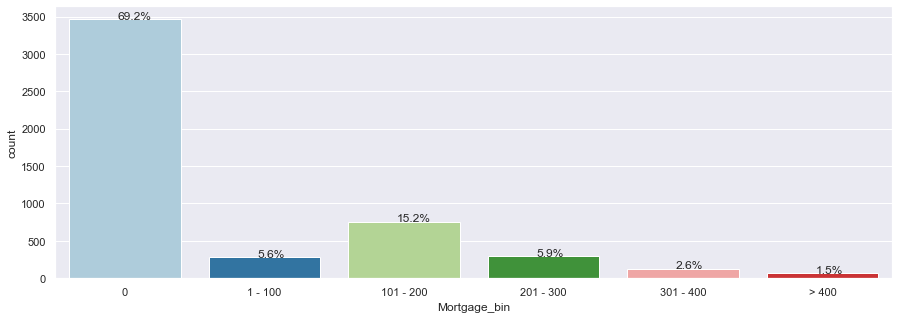

```python
perc_on_bar(loans['Mortgage_bin'])
```

The majority of the customers don't have a mortgage with 69% of the observations. 15% of customers have a mortgage between 101K USD and 200K USD. Remaining mortgage brackets are at 6% or less each.

##### Personal_Loan

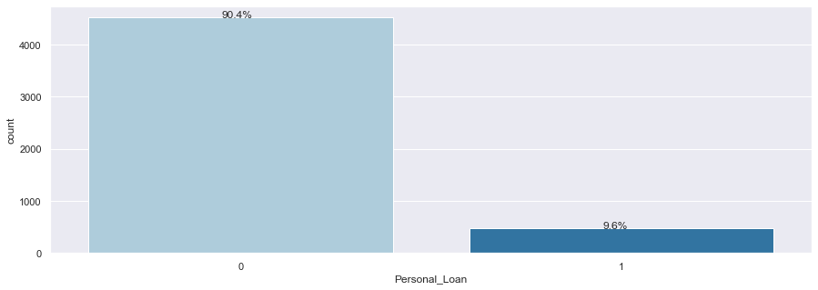

```python
perc_on_bar(loans['Personal_Loan'])
```

90.4% of customers do not have a personal loan with the bank. The class is imbalanced, weights will be used to compensate for that in the classification.

##### Securities_Account

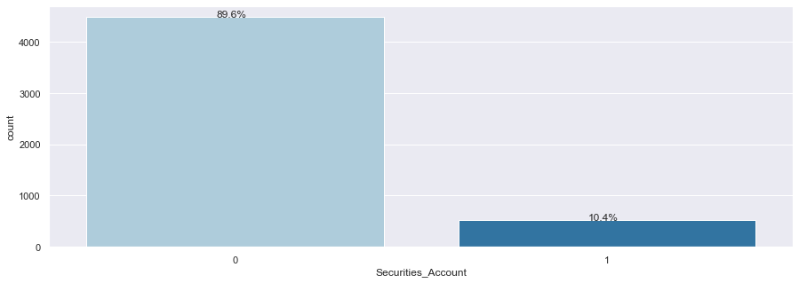

```python
perc_on_bar(loans['Securities_Account'])
```

Only 10% of customers have a securities account

##### CD_Account

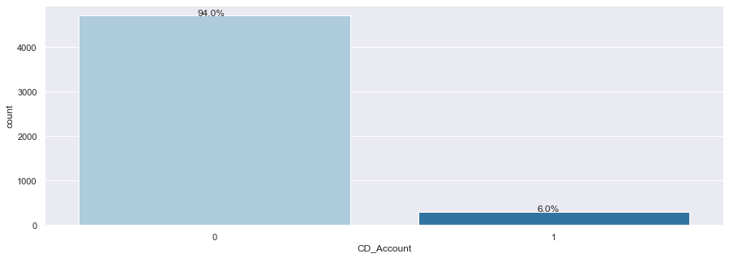

```python
perc_on_bar(loans['CD_Account'])
```

94% of customers do not have a certificate of deposit account.

##### Online

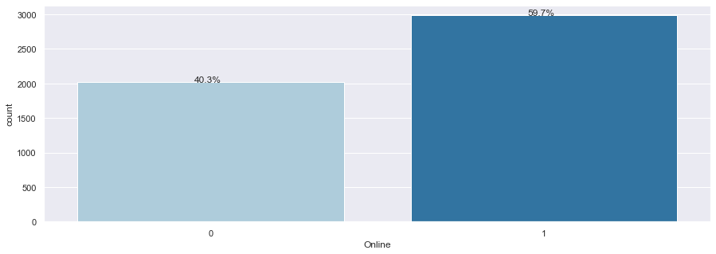

```python
perc_on_bar(loans['Online'])
```

60% of customers use online banking.

##### CreditCard

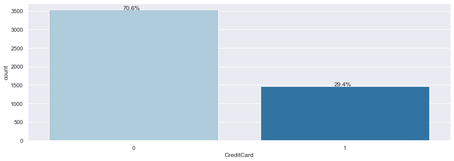

```python
perc_on_bar(loans['CreditCard'])
```

### Bivariate analysis

```python
loans.dtypes
```

```
Age                      int64
Experience               int64
Income                   int64
Family                category
Education             category
Personal_Loan            int64
Securities_Account       int64
CD_Account               int64
Online                   int64
CreditCard               int64
ZIPCode_cat           category
CCAvg_log              float64
Mortgage_bin          category
dtype: object
```

#### Numerical

```python
# get numerical cols
numeric_col = loans.select_dtypes(exclude=['category', 'object']).columns.to_list()

# remove Personal_Loan from the pairplot columns as the pairwise plots with Personal_Loan are not informative
numeric_col.remove('Personal_Loan')
```

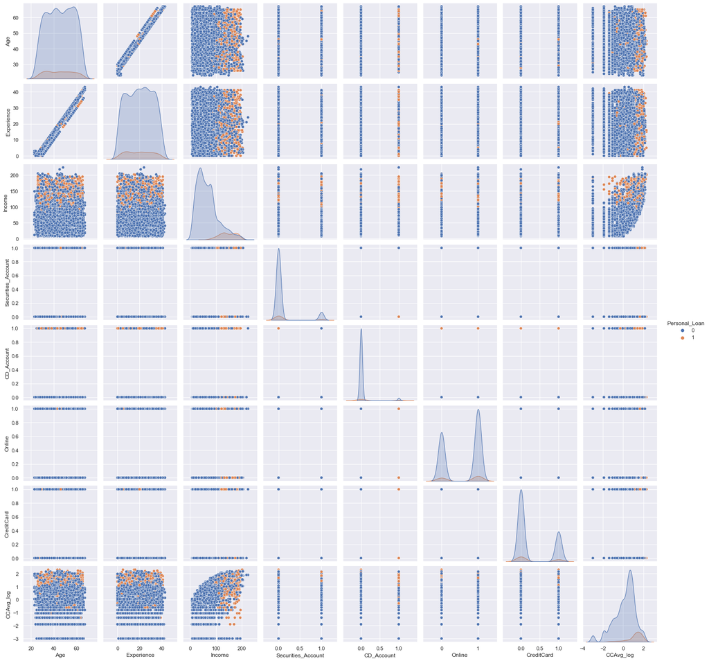

```python
# get plot of each pair and use Personal_Loan for hue
sns.pairplot(loans, vars=numeric_col, hue='Personal_Loan')
```

- People who have a personal loan are evenly distributed across Age and Experience
- People who have a personal loan tend to have higher CCAvg_log
- People who accepted a personal tend to have higher income
- Age and Experience are highly correlated.

##### Correlations

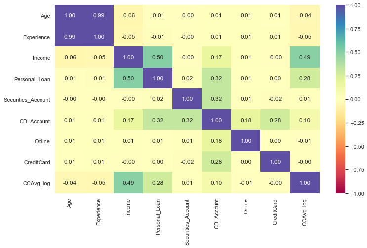

```python
# plot correlation matrix
plt.figure(figsize=(12, 7))
sns.heatmap(
    loans.corr(), annot=True, vmin=-1, vmax=1, fmt=".2f", cmap="Spectral"
)
plt.show()
```

- Age and Experience are almost perfectly correlated. We will drop Experience.

```python
# Drop Experience
loans.drop('Experience', axis=1, inplace=True)
```

#### Categorical

```python
### Function to plot stacked bar charts for categorical columns
def stacked_plot(data, x, y):
    ''' Plot stacked bar charts.
        data = dataframe,
        x = categorical column to plot across x axis
        y = categorical column to stack
    '''
    sns.set()
    ## crosstab
    tab1 = pd.crosstab(data[x],data[y],margins=True)
    print(tab1)
    print('-'*120)
    ## visualising the cross tab
    tab = pd.crosstab(data[x],data[y],normalize='index')
    tab.plot(kind='bar',stacked=True,figsize=(17,7))
    plt.legend(loc='lower left', frameon=False,)
    plt.legend(loc="upper left", bbox_to_anchor=(1,1))
    plt.show()
```

##### Family

```
Personal_Loan     0    1   All
Family
1              1365  107  1472
2              1190  106  1296
3               877  133  1010
4              1088  134  1222
All            4520  480  5000
------------------------------------------------------------------------------------------------------------------------
```

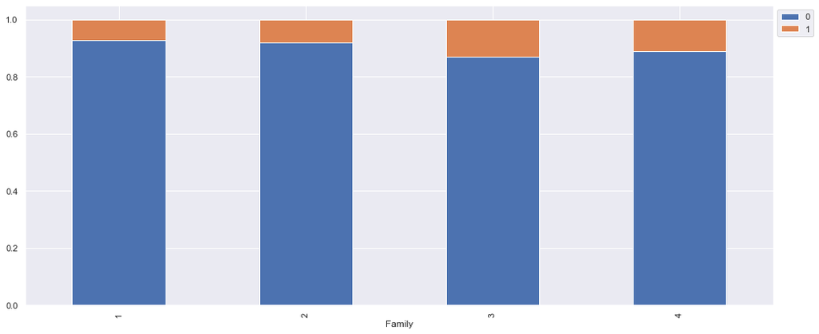

```python
stacked_plot(loans, 'Family', 'Personal_Loan')
```

Customers with 3 or 4 family members accepted a personal loans at a higher rate than those with 1 or 2

##### Education

```
Personal_Loan     0    1   All
Education
1              2003   93  2096
2              1221  182  1403
3              1296  205  1501
All            4520  480  5000
------------------------------------------------------------------------------------------------------------------------
```

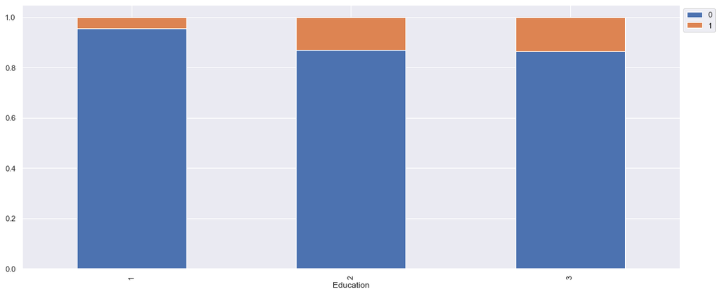

```python
stacked_plot(loans, 'Education', 'Personal_Loan')
```

A smaller percentage of customers with Undergraduate education (1) accepted loans. While Graduate (2) and Advanced accepted at about the same rate.

##### Securities_Account

```
Personal_Loan          0    1   All
Securities_Account
0                   4058  420  4478
1                    462   60   522
All                 4520  480  5000
------------------------------------------------------------------------------------------------------------------------
```

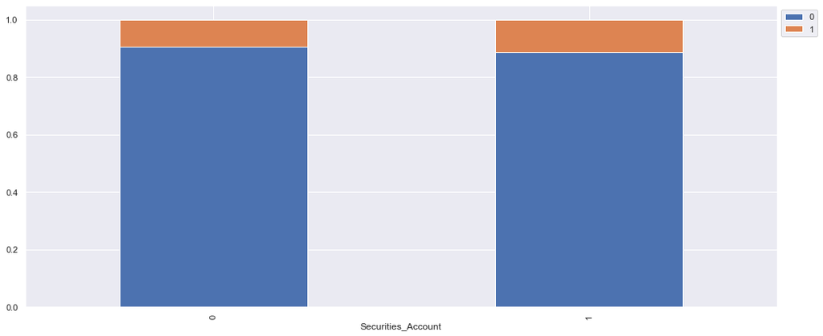

```python
stacked_plot(loans, 'Securities_Account', 'Personal_Loan')
```

Customers with a Securities account tended to accept personal loan at a slightly higher rate.

##### CD_Account

```
Personal_Loan     0    1   All
CD_Account
0              4358  340  4698
1               162  140   302
All            4520  480  5000
------------------------------------------------------------------------------------------------------------------------
```

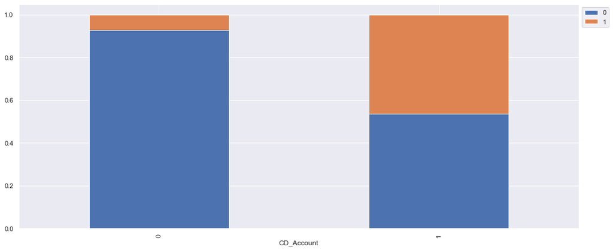

```python
stacked_plot(loans, 'CD_Account', 'Personal_Loan')
```

Customers with a CD Account accepted personal loans at a significantly higher rate than the rest.

##### Online

```
Personal_Loan     0    1   All
Online
0              1827  189  2016
1              2693  291  2984
All            4520  480  5000
------------------------------------------------------------------------------------------------------------------------
```

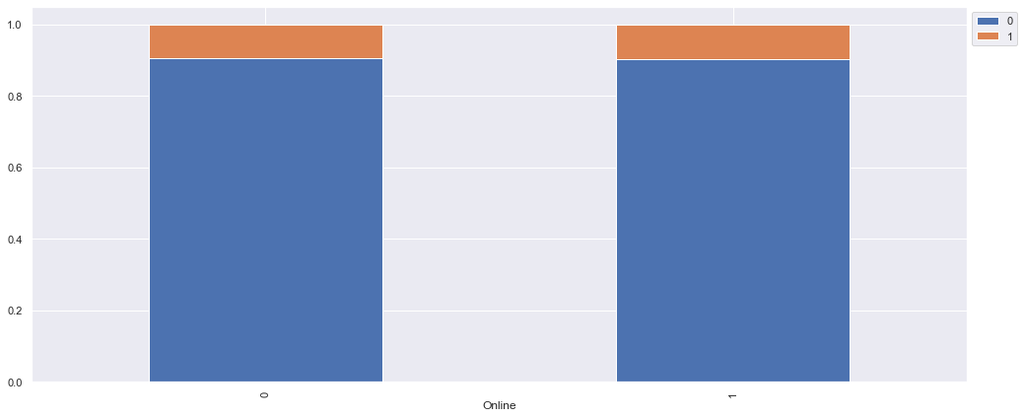

```python
stacked_plot(loans, 'Online', 'Personal_Loan')
```

The use of online banking did not make a significant difference in the acceptance rate of personal loans

###### CreditCard

```
Personal_Loan     0    1   All
CreditCard
0              3193  337  3530
1              1327  143  1470
All            4520  480  5000
------------------------------------------------------------------------------------------------------------------------
```

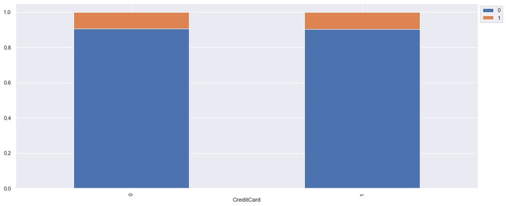

```python
stacked_plot(loans, 'CreditCard', 'Personal_Loan')
```

The use of another banks's credit card did not correspond to a significant difference in the acceptance rate of personal loans

```
Personal_Loan     0    1   All
ZIPCode_cat
90095            63    8    71
91320            51    2    53
91711            48    4    52
92037            49    5    54
93106            53    4    57
93943            50    4    54
94025            48    4    52
94305           114   13   127
94720           150   19   169
95616           110    6   116
Other          3784  411  4195
All            4520  480  5000
------------------------------------------------------------------------------------------------------------------------
```

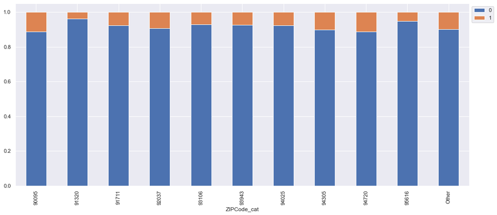

```python
stacked_plot(loans, 'ZIPCode_cat', 'Personal_Loan')
```

Acceptance rates of personal loans vary across ZIP codes.

##### Mortage_bin

```
Personal_Loan     0    1   All
Mortgage_bin
0              3150  312  3462
1 - 100         269   13   282
101 - 200       719   39   758
201 - 300       257   40   297
301 - 400        88   40   128
> 400            37   36    73
All            4520  480  5000
------------------------------------------------------------------------------------------------------------------------
```

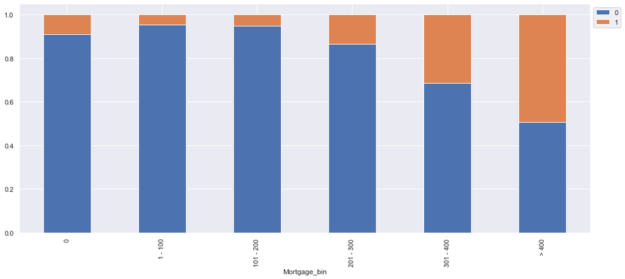

```python
stacked_plot(loans, 'Mortgage_bin', 'Personal_Loan')
```

### Summary of EDA and pre-processing

**Data Description**

- There are no missing values in dataset
- All original variables were stored as numeric types
- Dependent variable is Personal_Loan which is of categorical type (0=No, 1=Yes)

**Data Cleaning**

- `Experience` had negative values that were converted to positive.

**Observations from EDA**

**Data Pre-processing**

### Model building

#### Model Evaluation

- Positive: customer accepted a personal loan (1)
- Negative: customer did not accept a personal loan (0)

#### Predictions

- False Positive (FP): Predicting the customer will accept loan offer but actually it will not get accepted.
  - We might spend time and resources on customers that are not receptive to the offer, leading to ineffective campaign.
- False Negative (FN): Predicting the customer will not accept a loan but actually it would have been accepted.
  - We would fail to target customers who could be converted to personal loan customers. This will lead to lost opportunities and lower revenues than what might have been otherwise.

We consider the cost of False Negatives higher than False Positive.

Accuracy and ROC-AUC are not good performance metrics as the predicted class is imbalanced.

We could use Recall as a metric to be optimized. However, we cannot just maximize it; a model that always predicts Positive will achieve $Recall = 1$ and provide no value to the business.

Based on the above consideratons, we'll optimize Precision and Recall.

#### Logistic Regression

We will first use a logistic regression model.

##### Data preparation

Encode categorical variables with dummy variables.

```python
X = loans.drop(['Personal_Loan'], axis=1)
Y = loans['Personal_Loan']

# Convert categoricals to dummy variables

# Since logistic regression in sklearn by default uses regularization we keep all columns
# https://stats.stackexchange.com/questions/231285/dropping-one-of-the-columns-when-using-one-hot-encoding
# https://inmachineswetrust.com/posts/drop-first-columns/

X = pd.get_dummies(X, drop_first=False)
X.columns
```

```
Index(['Age', 'Income', 'Securities_Account', 'CD_Account', 'Online',
       'CreditCard', 'CCAvg_log', 'Family_1', 'Family_2', 'Family_3',
       'Family_4', 'Education_1', 'Education_2', 'Education_3',
       'ZIPCode_cat_90095', 'ZIPCode_cat_91320', 'ZIPCode_cat_91711',
       'ZIPCode_cat_92037', 'ZIPCode_cat_93106', 'ZIPCode_cat_93943',
       'ZIPCode_cat_94025', 'ZIPCode_cat_94305', 'ZIPCode_cat_94720',
       'ZIPCode_cat_95616', 'ZIPCode_cat_Other', 'Mortgage_bin_0',
       'Mortgage_bin_1 - 100', 'Mortgage_bin_101 - 200',
       'Mortgage_bin_201 - 300', 'Mortgage_bin_301 - 400',
       'Mortgage_bin_> 400'],
      dtype='object')
```

Split data into train and test sets

```python
X_train, X_test, y_train, y_test = train_test_split(X, Y, test_size=0.3, random_state=1)
print(X_train.shape, X_test.shape)
```

```
(3500, 31) (1500, 31)
```

#### Define function to compute metrics of models

```python
def get_metrics_score(model,train,test,train_y,test_y,threshold=0.5,print_values=True,roc=False):
    '''
    Function to calculate different metric scores of the model - Accuracy, Recall, Precision, and F1 score
    model: classifier to predict values of X
    train, test: Independent features
    train_y,test_y: Dependent variable
    threshold: thresold for classifiying the observation as 1
    flag: If the flag is set to True then only the print statements showing different will be displayed.
        The default value is set to True.
    roc: If the roc is set to True then only roc score will be displayed. The default value is set to False.
    '''
    # defining an empty list to store train and test results

    score_list=[]

    pred_train = (model.predict_proba(train)[:,1]>threshold)
    pred_test = (model.predict_proba(test)[:,1]>threshold)

    pred_train = np.round(pred_train)
    pred_test = np.round(pred_test)

    train_acc = metrics.accuracy_score(pred_train,train_y)
    test_acc = metrics.accuracy_score(pred_test,test_y)

    train_recall = metrics.recall_score(train_y,pred_train)
    test_recall = metrics.recall_score(test_y,pred_test)

    train_precision = metrics.precision_score(train_y,pred_train)
    test_precision = metrics.precision_score(test_y,pred_test)

    train_f1 = metrics.f1_score(train_y,pred_train)
    test_f1 = metrics.f1_score(test_y,pred_test)


    score_list.extend((train_acc,test_acc,train_recall,test_recall,train_precision,test_precision,train_f1,test_f1))


    if print_values == True:
        print("Accuracy - training      : ", train_acc)
        print("Accuracy - test          : ", test_acc)
        print("Recall - training        : ", train_recall)
        print("Recall - test            : ", test_recall)
        print("Precision - training     : ", train_precision)
        print("Precision - test         : ", test_precision)
        print("F1 - training            : ", train_f1)
        print("F1 - test                : ", test_f1)

    if roc == True:
        pred_train_prob = model.predict_proba(train)[:,1]
        pred_test_prob = model.predict_proba(test)[:,1]
        print("ROC-AUC Score - training : ", metrics.roc_auc_score(train_y,pred_train))
        print("ROC-AUC Score - test     : ", metrics.roc_auc_score(test_y,pred_test))

    return score_list # returning the list with train and test scores
```

```python
def plot_confusion_matrix(model, X, y_actual, threshold=0.5):
    '''Plot confusion matrix from model, X and y_actual.
    '''
#    y_predict = model.predict(X)
    y_predict = (model.predict_proba(X)[:,1]>threshold)
    cm = metrics.confusion_matrix(y_actual, y_predict)
    # print(cm.flatten())
    # https://scikit-learn.org/stable/modules/generated/sklearn.metrics.confusion_matrix.html
    TN = cm[0,0]
    FP = cm[0,1]
    FN = cm[1,0]
    TP = cm[1,1]
    # print(f'TN:{TN}, FN:{FN}, TP:{TP}, FP:{FP}')
    accuracy  = (TP + TN) / (TN+FN+TP+FP)
    precision = TP / (TP + FP)
    recall    = TP / (TP + FN)
    f1_score  = 2 * precision * recall / (precision + recall)
    scores = "\n\nAccuracy={:0.3f}\nPrecision={:0.3f}\nRecall={:0.3f}\nF1 Score={:0.3f}".format(accuracy,precision,recall,f1_score)
    df_cm = pd.DataFrame(cm, index = [i for i in ["0","1"]],
                  columns = [i for i in ["Predict 0","Predict 1"]])
    group_names = ['TN', 'FP','FN','TP']
    group_counts = ["{0:0.0f}".format(value) for value in
                cm.flatten()]
    group_percentages = ["{0:.2%}".format(value) for value in
                     cm.flatten()/np.sum(cm)]
    labels = [f"{v1}\n{v2}\n{v3}" for v1, v2, v3 in
          zip(group_names,group_counts,group_percentages)]
    labels = np.asarray(labels).reshape(2,2)

    sns.heatmap(df_cm, annot=labels, fmt='', cmap='Spectral')
    print(scores)
```

### Logistic Regression

Train a logistic regression model.

```python
# train a logistic regression on the train data
lgr = LogisticRegression(solver='lbfgs', random_state=1, class_weight='balanced')
lgr.fit(X_train, y_train)
```

```
LogisticRegression(class_weight='balanced', random_state=1)
```

Print the model metrics

```python
# get metrics of the model performance
get_metrics_score(lgr, X_train, X_test, y_train, y_test);
```

```
Accuracy - training      :  0.9137142857142857
Accuracy - test          :  0.9093333333333333
Recall - training        :  0.9154078549848943
Recall - test            :  0.8523489932885906
Precision - training     :  0.5251299826689775
Precision - test         :  0.5269709543568465
F1 - training            :  0.6674008810572687
F1 - test                :  0.6512820512820514
```

```
Accuracy=0.909
Precision=0.527
Recall=0.852
F1 Score=0.651
```

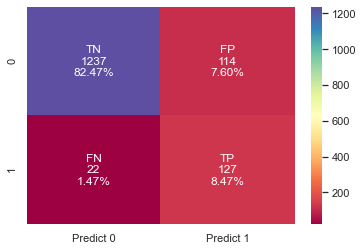

```python
# plot confusion metrics - TEST data
plot_confusion_matrix(lgr,X_test, y_test)
```

Recall is high at 85% on test data. However, precision is very low.

We will tune the threshold to optimize Precision/Recall.

##### Threshold vs Precision/Recall - Train data

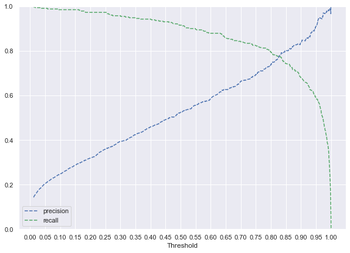

```python
# Plot threshold vs Precision/Recall train set
y_scores=lgr.predict_proba(X_train)[:,1]
prec, rec, tre = metrics.precision_recall_curve(y_train, y_scores,)

def plot_prec_recall_vs_tresh(precisions, recalls, thresholds):
    fig = plt.figure(figsize=(10,7))
    ax = fig.add_subplot(1, 1, 1)
    ax.plot(thresholds, precisions[:-1], 'b--', label='precision')
    ax.plot(thresholds, recalls[:-1], 'g--', label = 'recall')
    plt.xlabel('Threshold')
    plt.legend(loc='lower left')
    plt.ylim([0,1])
    ax.set_xticks(np.arange(0,1.05,0.05))
    ax.grid(markevery=10, which='major')
plot_prec_recall_vs_tresh(prec, rec, tre)
plt.show()
```

Optimal threshold for train set is ~0.83

##### Threshold vs Precision/Recall - Test data

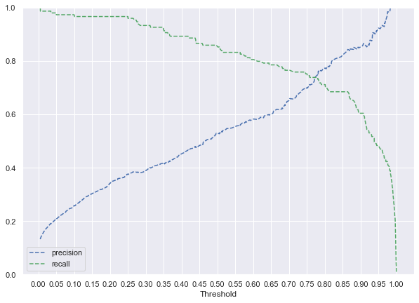

```python
# Plot threshold vs Precision/Recall test set
y_scores=lgr.predict_proba(X_test)[:,1]
prec, rec, tre = metrics.precision_recall_curve(y_test, y_scores,)
plt.figure(figsize=(10,7))
plot_prec_recall_vs_tresh(prec, rec, tre)
plt.show()
```

The optimal threshold for test data is ~ 0.77

##### Compute metrics and plot confusion matrix with optimized thresholds

```python
opt_threshold_train = 0.83
opt_threshold_test = 0.77
# get metrics with optimized threshold
print(f"\nThreshold: {opt_threshold_train}\n======================")
get_metrics_score(lgr, X_train, X_test, y_train, y_test, threshold=opt_threshold_train);
print(f"\nThreshold: {opt_threshold_test}\n======================")
get_metrics_score(lgr, X_train, X_test, y_train, y_test, threshold=opt_threshold_test);
```

```
Threshold: 0.83
======================
Accuracy - training      :  0.9582857142857143
Accuracy - test          :  0.9526666666666667
Recall - training        :  0.7734138972809668
Recall - test            :  0.6845637583892618
Precision - training     :  0.7828746177370031
Precision - test         :  0.8095238095238095
F1 - training            :  0.7781155015197568
F1 - test                :  0.7418181818181819

Threshold: 0.77
======================
Accuracy - training      :  0.9508571428571428
Accuracy - test          :  0.946
Recall - training        :  0.8126888217522659
Recall - test            :  0.738255033557047
Precision - training     :  0.7097625329815304
Precision - test         :  0.7236842105263158
F1 - training            :  0.7577464788732394
F1 - test                :  0.7308970099667774
```

For test Recall is higher (0.738 vs 0.684) with threshold 0.77 but we trade off Precision (from 0.81 to 0.72). The model is overfitting as there is 8-9% difference between train and test scores.

F1 score is sligthly higher with 0.83 threshold.

As we favor Recall, for prediction purposes the recommended threshold is 0.77.

#### Final Confusion Matrix for Logistic Regression

```
Accuracy=0.946
Precision=0.724
Recall=0.738
F1 Score=0.731
```

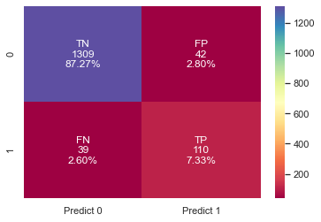

```python
plot_confusion_matrix(lgr, X_test, y_test, threshold=0.77)
```

```python
# compute odds as exp(log(odds))
log_odds = lgr.coef_[0]
pd.DataFrame(log_odds, X_train.columns, columns=['coef']).T
```

|  | Age | Income | Securities_Account | CD_Account | Online | CreditCard | CCAvg_log | Family_1 | Family_2 | Family_3 | Family_4 | Education_1 | Education_2 | Education_3 | ZIPCode_cat_90095 | ZIPCode_cat_91320 | ZIPCode_cat_91711 | ZIPCode_cat_92037 | ZIPCode_cat_93106 | ZIPCode_cat_93943 | ZIPCode_cat_94025 | ZIPCode_cat_94305 | ZIPCode_cat_94720 | ZIPCode_cat_95616 | ZIPCode_cat_Other | Mortgage_bin_0 | Mortgage_bin_1 - 100 | Mortgage_bin_101 - 200 | Mortgage_bin_201 - 300 | … |
| --- | --- | --- | --- | --- | --- | --- | --- | --- | --- | --- | --- | --- | --- | --- | --- | --- | --- | --- | --- | --- | --- | --- | --- | --- | --- | --- | --- | --- | --- | --- |
| coef | 0.002505 | 0.05623 | -1.352703 | 3.57034 | -0.618875 | -0.812512 | 0.788208 | -1.675582 | -1.635392 | 0.199936 | -0.273727 | -2.969108 | -0.304219 | -0.111438 | -0.749343 | -0.479837 | -0.283138 | -0.114565 | 0.063523 | -0.442756 | -0.501212 | 0.276848 | -0.375931 | -0.865126 | 0.086772 | -0.713782 | -0.206923 | -1.091381 | -0.751238 | … |

```python
# compute odds as exp(log(odds))
odds = np.exp(lgr.coef_[0])
pd.DataFrame(odds, X_train.columns, columns=['odds']).T
```

|  | Age | Income | Securities_Account | CD_Account | Online | CreditCard | CCAvg_log | Family_1 | Family_2 | Family_3 | Family_4 | Education_1 | Education_2 | Education_3 | ZIPCode_cat_90095 | ZIPCode_cat_91320 | ZIPCode_cat_91711 | ZIPCode_cat_92037 | ZIPCode_cat_93106 | ZIPCode_cat_93943 | ZIPCode_cat_94025 | ZIPCode_cat_94305 | ZIPCode_cat_94720 | ZIPCode_cat_95616 | ZIPCode_cat_Other | Mortgage_bin_0 | Mortgage_bin_1 - 100 | Mortgage_bin_101 - 200 | Mortgage_bin_201 - 300 | … |
| --- | --- | --- | --- | --- | --- | --- | --- | --- | --- | --- | --- | --- | --- | --- | --- | --- | --- | --- | --- | --- | --- | --- | --- | --- | --- | --- | --- | --- | --- | --- |
| odds | 1.002508 | 1.057841 | 0.25854 | 35.52868 | 0.53855 | 0.443742 | 2.199451 | 0.187199 | 0.194876 | 1.221325 | 0.76054 | 0.051349 | 0.737699 | 0.894547 | 0.472677 | 0.618884 | 0.753416 | 0.891754 | 1.065584 | 0.642264 | 0.605796 | 1.318966 | 0.686649 | 0.420998 | 1.090648 | 0.489788 | 0.813082 | 0.335752 | 0.471782 | … |

```python
# percent odds change
perc_change_odds = (np.exp(lgr.coef_[0])-1)*100 # finding the percentage change
pd.set_option('display.max_columns',None) # removing limit from number of columns to display
pd.DataFrame(perc_change_odds, X_train.columns, columns=['change_odds%']).T # adding the change_odds% to a dataframe
```

|  | Age | Income | Securities_Account | CD_Account | Online | CreditCard | CCAvg_log | Family_1 | Family_2 | Family_3 | Family_4 | Education_1 | Education_2 | Education_3 | ZIPCode_cat_90095 | ZIPCode_cat_91320 | ZIPCode_cat_91711 | ZIPCode_cat_92037 | ZIPCode_cat_93106 | ZIPCode_cat_93943 | ZIPCode_cat_94025 | ZIPCode_cat_94305 | ZIPCode_cat_94720 | ZIPCode_cat_95616 | ZIPCode_cat_Other | Mortgage_bin_0 | Mortgage_bin_1 - 100 | Mortgage_bin_101 - 200 | Mortgage_bin_201 - 300 | … |
| --- | --- | --- | --- | --- | --- | --- | --- | --- | --- | --- | --- | --- | --- | --- | --- | --- | --- | --- | --- | --- | --- | --- | --- | --- | --- | --- | --- | --- | --- | --- |
| change_odds% | 0.250843 | 5.784131 | -74.145957 | 3452.868019 | -46.145001 | -55.625806 | 119.945089 | -81.280082 | -80.512412 | 22.132492 | -23.946025 | -94.86509 | -26.230067 | -10.545342 | -52.732278 | -38.111571 | -24.658405 | -10.824584 | 6.558357 | -35.773633 | -39.420426 | 31.896632 | -31.335053 | -57.900161 | 9.064839 | -51.021152 | -18.691784 | -66.42476 | -52.821785 | … |